# Biomedical Statistics Homework 04

- Show All Code
- Hide All Code
- View Source

Author

Zipeng YE (CEBSIT, CAS)

# 1 Question 1

## 1.1 建立自动化统计分析流程

两组数据（S、R）均为 $n \le 30$ 的小样本，自动化统计分析流程逻辑如下：

1. **正态性检验**：对两组数据分别执行 **Shapiro-Wilk test**。
2. **方差齐性检验**：若两组均满足正态分布（$p > 0.05$），则执行 **F-test**。
   - 方差齐（$p > 0.05$) $\rightarrow$ **Student’s t-test**
   - 方差不齐（$p \le 0.05$）$\rightarrow$ **Welch’s t-test**
3. 若任意一组不满足正态分布（$p \le 0.05$），则跳过方差齐性检验，直接使用非参数检验 $\rightarrow$ **Wilcoxon rank-sum test**。

```r
library(dplyr)
library(knitr) # 用于格式化表格输出

# 读取数据
data <- read.csv("data/raw/homework4-Q1-data.csv",
                 stringsAsFactors = FALSE) # 避免字符串被自动转换为因子

# 初始化空数据框用于存储结果
results <- data.frame(
  Gene = character(),      # 基因名称
  Method = character(),    # 使用的检验方法
  p_value = numeric(),     # 原始 p-value
  log2FC = numeric(),      # log2 fold change
  stringsAsFactors = FALSE
)

# 遍历每一个基因执行自动化流程
for (i in 1:nrow(data)) {
  # 提取基因名称
  gene_name <- data$Gene[i]

  # 提取 Condition A（Sensitive）和 Condition B（Resistant）
  S <- as.numeric(data[i, 2:11])
  R <- as.numeric(data[i, 12:21])

  # 1. Shapiro-Wilk 正态性检验
  p_norm_S <- shapiro.test(S)$p.value
  p_norm_R <- shapiro.test(R)$p.value

  if (p_norm_S > 0.05 && p_norm_R > 0.05) {
    # 2. 正态前提满足，进行方差齐性检验，根据结果选择 t 检验类型
    p_var <- var.test(R, S)$p.value

    if (p_var > 0.05) {
      # 方差齐，使用 Student's t-test
      method <- "Student's t-test"
      test_res <- t.test(R, S, var.equal = TRUE) # 默认是双尾检验
    } else {
      # 方差不齐，使用 Welch's t-test
      method <- "Welch's t-test"
      test_res <- t.test(R, S, var.equal = FALSE)
    }
  } else {
    # 3. 违反正态性假设，跳过方差齐性检验，直接使用非参数检验
    method <- "Wilcoxon rank-sum test"
    test_res <- wilcox.test(R, S) # 默认是双尾检验，且不需要设置 var.equal 参数
  }

  # 提取 p-value 和 log2FC
  p_val <- test_res$p.value
  log2fc <- mean(R) - mean(S)

  # 记录结果（将分析结果按行添加到 results 数据框中）
  results <- rbind(results, data.frame(
    Gene = gene_name,
    Method = method,
    p_value = p_val,
    log2FC = log2fc
  ))
}
```

## 1.2 BH-FDR 校正

### 1.2.1 BH-FDR 公式与解释

Benjamini-Hochberg（BH）方法用于控制错误发现率（False Discovery Rate, FDR）， 即在所有拒绝 $H_0$（宣称有显著差异/阳性）的基因中，假阳性结果所占的预期比例。

**计算公式：** 将 $m$ 次检验的 p 值从小到大排列：$p_{(1)} \le p_{(2)} \le \dots \le p_{(m)}$。 对于第 $i$ 个排位的检验，其校正后的 p 值（Adjusted p-value / q-value）计算如下：

$$P.adj_{(i)} = \min \left( p_{(i)} \times \frac{m}{i},\ \min_{j > i} P.adj_{(j)} \right)$$

实践中，该公式从排名最大的检验（$i = m$）开始向前迭代计算， 确保校正后的 p 值保持单调不减。

- **解读**：某个基因的 p 值会乘以一个调整系数 $\frac{m}{i}$。 排名 $i$ 越靠后（p 值越大），系数 $\frac{m}{i}$ 越小，意味着乘法惩罚越轻； 排名越靠前（p 值越小），系数越大，惩罚越重——当 $i=1$ 时， 惩罚力度等同于课堂上提到的最保守的 Bonferroni 校正（直接乘以检验次数 $m$）。 但由于这些检验本身的 p 值极小，即便系数较大，校正后仍常常保持显著。 公式中对排名更靠后的 $P.adj$ 取最小值，是为了保证单调性： 校正后的 p 值不会随排名升高而出现下降，使结果在解释上自洽。 最终，校正后的 p 值被截断在 1 以内，以保持其概率的含义。 该方法通过这一动态调整机制，在发现新信号和控制假阳性之间取得了平衡。

### 1.2.2 执行 BH 校正

```r
# 利用 p.adjust 函数进行 BH-FDR 校正
results$q_value <- p.adjust(results$p_value, method = "BH")

# 格式化输出结果，便于阅读
results_display <- results %>%
  mutate(
    p_value = formatC(p_value, format = "e", digits = 2),
    q_value = formatC(q_value, format = "e", digits = 2),
    log2FC = round(log2FC, 2)
  ) # "formatC()" 函数用于科学计数法（指定 format = "e"）格式化 p 值

kable(results_display,
      caption = "Automated Hypothesis Testing & FDR Correction Results")
```

Automated Hypothesis Testing & FDR Correction Results

| Gene | Method | p_value | log2FC | q_value |
| --- | --- | --- | --- | --- |
| MYC | Wilcoxon rank-sum test | 1.78e-04 | -3.97 | 2.14e-04 |
| BCL2 | Wilcoxon rank-sum test | 1.77e-04 | 3.02 | 2.14e-04 |
| RAD51 | Wilcoxon rank-sum test | 1.79e-04 | -3.96 | 2.14e-04 |
| BRCA1 | Wilcoxon rank-sum test | 1.78e-04 | -2.89 | 2.14e-04 |
| PARP1 | Wilcoxon rank-sum test | 1.78e-04 | -3.17 | 2.14e-04 |
| MKI67 | Wilcoxon rank-sum test | 1.79e-04 | -4.88 | 2.14e-04 |
| ATP5F1A | Wilcoxon rank-sum test | 1.76e-04 | 4.88 | 2.14e-04 |
| NDUFS2 | Wilcoxon rank-sum test | 1.74e-04 | 4.90 | 2.14e-04 |
| TP53 | Student’s t-test | 1.03e-07 | 0.55 | 6.16e-07 |
| BAX | Welch’s t-test | 1.94e-10 | -1.95 | 2.32e-09 |
| GAPDH | Student’s t-test | 5.45e-01 | -0.03 | 5.45e-01 |
| ACTB | Student’s t-test | 1.76e-01 | -0.08 | 1.92e-01 |

## 1.3 RNA-seq 偏好 BH-FDR 而非 Bonferroni 的可能原因

在 RNA-seq 等高通量组学分析中，BH-FDR 被广泛采用，而极少使用 Bonferroni（$P_{adj} = p \times m$），主要基于以下统计学与生物学考量：

1. **FWER 与 FDR 的本质区别**：Bonferroni 严格控制族错误率（Family-wise error rate, FWER），其目标是“在 $m$ 次检验中，出现至少一个假阳性的概率都 $\le \alpha$”。对于 RNA-seq（动辄 $m > 20000$），这种控制过于严苛保守。而 FDR 允许一定比例的假阳性（如设 $FDR < 0.05$ 意味着选出的 100 个差异基因中允许约 5 个是假阳性），这在发现型研究中完全可以接受。
2. **BH 可降低 Type II error（提高统计功效）**：课堂上重点提到，Bonferroni 由于 $m$ 极大，可能会将显著性阈值压低到如 $p < 2.5 \times 10^{-6}$，这会导致**假阴性率 $\beta$ 激增**，丢失大量真正具有生物学意义的弱差异表达基因，**极大损害统计功效（$1 - \beta$）**。
3. **基因间的相关性结构实际上有利于 BH**：BH 方法在检验相互独立或正相关依赖时，被严格证明能控制 FDR。RNA-seq 中基因表达的正相关性（如共同通路的基因协同变化）恰好满足这一条件。相比之下，Bonferroni 虽然对任何依赖结构都成立（基于 Boole 不等式，不需要独立性），但在测试正相关时会变得更加保守，进一步损害统计功效。

## 1.4 t 检验前的前提假设检验必要性及离群值影响

### 1.4.1 为何需要执行正态性检验和方差齐性检验？

- **正态性检验**：Student’s 和 Welch’s t 检验的底层理论推导（构建 t 统计量）均假设样本所属的总体服从正态分布。当样本量较小（如本题 $n=10$），无法依赖中心极限定理，若强行对偏态数据进行 t 检验，会导致真实的 Type I error 偏离预设的 $\alpha$ 水平。
- **方差齐性检验**：标准的 Student’s t 检验在计算标准误时，会使用**合并方差**。如果两组方差差异悬殊却强行合并，会导致方差较大的一组被低估、较小的一组被高估，得出错误结果。若方差不齐，必须转而使用调整了自由度的 **Welch’s t-test**。（此外，合并方差的优势在于自由度略高，因此会有更大的统计功效，且置信区间更窄。但前提是方差齐性成立，否则反而适得其反。）

### 1.4.2 离群值对 t 检验的影响

观察本题中的 *MYC*、*BCL2* 等基因的数据可以发现个别明显的极端值（如 15.5），离群值对 t 检验会产生如下影响：

- **影响均值**：离群值会极大地把样本均值向自身方向“拉扯”。这可能导致原本无差异的两组被强行拉出假差异（假阳性）。
- **影响方差**：方差计算中采用的是偏差的平方 $(x - \bar{x})^2$。一个离群值会使该组的样本方差增大，进而增大 t 检验的分母（标准误）。此时，即使两组真实的均值存在差异，也会因为分母过大导致 t 统计量减小，掩盖真实差异（假阴性）。

# 2 Question 2

## 2.1 计算给定样本量下的统计功效

**题目条件**：显著性水平 $\alpha = 0.05$，目标检测效应量 Cohen’s $d = 0.6$，每组样本量 $n = 35$。求统计功效。

**检验类型**：大样本量（$n > 30$）条件下，两独立样本的均值比较，应使用两样本 t 检验。

```r
library(pwr)

# 定义已知常量
alpha <- 0.05   # 显著性水平
target_d <- 0.6 # 目标效应量（Cohen's d）

# 本小题给定的样本量
n_per_group <- 35

# 计算统计功效
# 将需要求解的参数（power）设置为 NULL
res_1 <- pwr.t.test(n = n_per_group, d = target_d, sig.level = alpha, power = NULL,
                    type = "two.sample", alternative = "two.sided")
res_1
```

```
     Two-sample t test power calculation

              n = 35
              d = 0.6
      sig.level = 0.05
          power = 0.696531
    alternative = two.sided

NOTE: n is number in *each* group
```

**结论:** 如果每组有 35 株水稻幼苗，该实验检测出中等效应量（$d=0.6$）的统计功效约为 69.7%。

## 2.2 计算达到目标功效所需的最小样本量

**题目条件**：显著性水平 $\alpha = 0.05$，目标效应量 $d = 0.6$，目标功效 Power $= 0.80$。求每组所需最小样本量 $n_{\text{min}}$。

**检验类型**：同样是两独立样本的均值比较，按题目要求使用两样本 t 检验。

```r
# 本小题给定的目标功效
target_power <- 0.80

# 计算所需最小样本量
# 将需要求解的参数（n）设置为 NULL
res_2 <- pwr.t.test(n = NULL, d = target_d, sig.level = alpha, power = target_power,
                    type = "two.sample", alternative = "two.sided")
res_2
```

```
     Two-sample t test power calculation

              n = 44.58577
              d = 0.6
      sig.level = 0.05
          power = 0.8
    alternative = two.sided

NOTE: n is number in *each* group
```

```r
# 向上取整得到实际需要的幼苗数量
min_n <- ceiling(res_2$n)
```

**结论:** 为了使统计功效达到 80%，计算得出的理论样本量为 44.586。由于数量必须是整数，需要向上取整。因此，每组至少需要 45 株水稻幼苗。

## 2.3 计算在受限样本量下能检测到的最小效应量

**题目条件**：由于温室空间限制，每组最多只能容纳 $n = 20$ 株幼苗。显著性水平 $\alpha = 0.05$。题目未指定目标功效，假定依然为 0.8。求在该受限条件下能检测到的最小效应量 $d_{\text{min}}$。

**检验类型**：还是两独立样本的均值比较，按题目要求使用两样本 t 检验。

```r
# 本小题给定的受限样本量
limited_n <- 20

# 计算最小可检测效应量
# 将需要求解的参数（d）设置为 NULL
res_3 <- pwr.t.test(n = limited_n, d = NULL, sig.level = alpha, power = target_power,
                    type = "two.sample", alternative = "two.sided")
res_3
```

```
     Two-sample t test power calculation

              n = 20
              d = 0.9091587
      sig.level = 0.05
          power = 0.8
    alternative = two.sided

NOTE: n is number in *each* group
```

**结论:** 当受限于空间，每组只能种植 20 株幼苗时（且要保证 80% 的统计功效），该实验所能检测到的最小效应量 Cohen’s $d$ 为 0.909。（注意：这个效应量比题目中原先设定的 0.6 要大，意味着在样本量受限的情况下，只有更大的效应才能被检测出来。）

# 3 Question 3

## 3.1 Step-by-step 手动计算 One-way ANOVA

### 3.1.1 假设陈述

- **$H_0$：**四种细胞系的感染效率（GFP 阳性百分比）总体均值相等，即 $\mu_{\text{CHO}} = \mu_{\text{HEK293T}} = \mu_{\text{Vero}} = \mu_{\text{BHK-21}}$。
- **$H_1$：**四种细胞系的感染效率（GFP 阳性百分比）总体均值不全相等，即至少存在两组 $\mu$ 不相等。
- **显著性水平：**$\alpha = 0.05$。

### 3.1.2 前提条件检验

1. **样本间相互独立**：不同的细胞系培养皿/ROI 之间互不干扰。
2. **样本为随机选取**：ROI 是在荧光显微镜下随机选择的。
   - *（以上两点由实验设计本身保证）*
3. **各总体近似服从正态分布**：下面将使用 Shapiro-Wilk 检验分别检查 4 个细胞系的数据。
4. **各总体方差近似相同**：下面将使用 Bartlett 检验来评估方差齐性。

```r
library(dplyr)
library(glue)

# 1. 读取数据
data <- read.csv("data/raw/homework4-Q3-data.csv",
                 stringsAsFactors = TRUE) # 将 CellLine 列自动转换为因子（作为分组变量），方便后续分析

# 2. 检验正态性（Shapiro-Wilk test for each cell line）
# 使用 tapply 对每个分组应用 shapiro.test，并提取 p-value
p_normality <- tapply(data$GFP_Positive_Percent, data$CellLine, function(x) shapiro.test(x)$p.value)
cat("正态性检验 p-values（若 > 0.05 则满足正态分布）:\n")
```

```
正态性检验 p-values（若 > 0.05 则满足正态分布）:
```

```r
print(p_normality)
```

```
    BHK21       CHO   HEK293T      Vero
0.9783548 0.8482115 0.6026268 0.6962227
```

```r
# 3. 检验方差齐性（Bartlett test）
bartlett_res <- bartlett.test(GFP_Positive_Percent ~ CellLine, data = data)
cat("\n方差齐性检验 p-value（若 > 0.05 则方差齐）:", bartlett_res$p.value, "\n")
```

```
方差齐性检验 p-value（若 > 0.05 则方差齐）: 0.978791
```

### 3.1.3 One-way ANOVA 手动计算

ANOVA 的数学原理是将总平方和（$SST$）分解为组间平方和（$SSB$）和组内平方和（$SSE$）：

- **$SST$ (Total Sum of Squares)**：所有数据点与总均值的差异。

$$SST = \sum_{i=1}^{N} (x_i - \bar{x})^2$$

- **$SSB$ (Between-group Sum of Squares)**：各组均值与总均值的差异（反映处理效应）。

$$SSB = \sum_{j=1}^{k} n_j (\bar{x}_j - \bar{x})^2$$

- **$SSE$ (Within-group Sum of Squares)**：组内各数据点与本组均值的差异（反映随机误差）。

$$SSE = \sum_{j=1}^{k} \sum_{i=1}^{n_j} (x_{ij} - \bar{x}_j)^2$$

自由度：

- 组间自由度 $df_B = k - 1$（$k$ 是组数）
- 组内自由度 $df_E = N - k$（$N$ 是总样本量）

均方（Mean Squares）：

- 组间均方 $MSB = \frac{SSB}{df_B}$
- 组内均方 $MSE = \frac{SSE}{df_E}$

F 统计量：

$$F = \frac{MSB}{MSE}$$

```r
# 获取基本参数
N <- nrow(data)                               # 总样本量（40）
k <- length(unique(data$CellLine))            # 分组数量（4）
grand_mean <- mean(data$GFP_Positive_Percent) # 总均值

# 计算各组的样本量、均值和方差
group_stats <- data %>%
  group_by(CellLine) %>% # 按 CellLine 分组
  summarise(
    n = n(),
    group_mean = mean(GFP_Positive_Percent),
    group_var = var(GFP_Positive_Percent)
  ) # 最终得到一个包含每组样本量、均值和方差的数据框
group_stats
```

```
# A tibble: 4 × 4
  CellLine     n group_mean group_var
  <fct>    <int>      <dbl>     <dbl>
1 BHK21       10       62.6      52.2
2 CHO         10       21.5      46.1
3 HEK293T     10       56.0      60.9
4 Vero        10       86.5      57.8
```

```r
# 1. 计算 SSB（组间平方和）
# 公式: sum( n_i * (mean_i - grand_mean)^2 )
SSB <- sum(group_stats$n * (group_stats$group_mean - grand_mean)^2)

# 2. 计算 SSE（组内平方和）
# 公式: sum( (n_i - 1) * var_i )
SSE <- sum((group_stats$n - 1) * group_stats$group_var)

# 3. 计算 SST（总平方和，验证 SST = SSB + SSE）
SST_manual <- SSB + SSE
SST_direct <- sum((data$GFP_Positive_Percent - grand_mean)^2) # 直接计算用于验算

# 4. 计算自由度（Degrees of Freedom）
df_B <- k - 1         # 组间自由度
df_E <- N - k         # 组内自由度

# 5. 计算均方（Mean Squares）
MSB <- SSB / df_B     # 组间均方
MSE <- SSE / df_E     # 组内均方

# 6. 计算 F 统计量和 p-value
F_stat <- MSB / MSE
# 查 F 分布表（右尾概率）
p_value <- pf(F_stat, df_B, df_E,
              lower.tail = FALSE) # lower.tail = FALSE 表示计算右尾概率，即 P(F > F_stat)

# 打印 ANOVA 表
cat(glue(
  "手动计算的 ANOVA 结果:\n",
  "(SSB+SSE -> SST: {sprintf('%.2f', SST_manual)}, 直接计算 SST: {sprintf('%.2f', SST_direct)})\n",
  "SSB: {sprintf('%.2f', SSB)}, df: {df_B}, MSB: {sprintf('%.2f', MSB)}\n",
  "SSE: {sprintf('%.2f', SSE)}, df: {df_E}, MSE: {sprintf('%.2f', MSE)}\n",
  "F-statistic: {sprintf('%.4f', F_stat)}\n",
  "p-value: {sprintf('%.2e', p_value)}\n"
))
```

```
手动计算的 ANOVA 结果:
(SSB+SSE -> SST: 23599.02, 直接计算 SST: 23599.02)
SSB: 21646.40, df: 3, MSB: 7215.47
SSE: 1952.61, df: 36, MSE: 54.24
F-statistic: 133.0302
p-value: 1.55e-19
```

**假设检验结论**： 手动计算得出的 p-value 为 1.55e-19，远小于 0.05，拒绝 $H_0$。这说明**至少有两种细胞系**对该病毒的易感性（感染效率）存在显著差异。

## 3.2 事后检验与数据可视化

ANOVA 表明“整体有差异”，需要使用 **Tukey’s HSD（Honest Significant Difference）**进行两两多重比较，以进一步确定是哪几个细胞系之间存在差异。Tukey 方法内置了多重比较的 p 值校正，以控制假阳性率。

*（注：由于 R 的 `TukeyHSD()` 函数强制要求输入一个 `aov` 类的模型对象，此处使用 `aov()` 函数快速拟合模型。）*

```r
# 1. Tukey's HSD 事后检验
# 构建 aov 模型对象
anova_model <- aov(GFP_Positive_Percent ~ CellLine, data = data)

# 运行 Tukey 检验
tukey_res <- TukeyHSD(anova_model)
print(tukey_res)
```

```
  Tukey multiple comparisons of means
    95% family-wise confidence level

Fit: aov(formula = GFP_Positive_Percent ~ CellLine, data = data)

$CellLine
                diff       lwr        upr     p adj
CHO-BHK21     -41.09 -49.96044 -32.219562 0.0000000
HEK293T-BHK21  -6.59 -15.46044   2.280438 0.2065963
Vero-BHK21     23.95  15.07956  32.820438 0.0000001
HEK293T-CHO    34.50  25.62956  43.370438 0.0000000
Vero-CHO       65.04  56.16956  73.910438 0.0000000
Vero-HEK293T   30.54  21.66956  39.410438 0.0000000
```

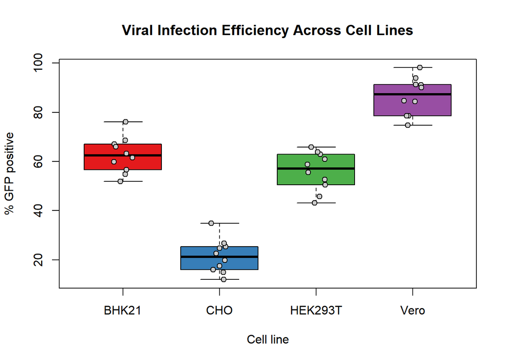

```r
# 2. 数据可视化：绘制箱线图
boxplot(GFP_Positive_Percent ~ CellLine, data = data,
        col = c("#E41A1C", "#377EB8", "#4DAF4A", "#984EA3"),
        main = "Viral Infection Efficiency Across Cell Lines",
        ylab = "% GFP positive",
        xlab = "Cell line",
        outline = FALSE) # 隐藏离群值轮廓，因为要叠加散点

# 叠加个体数据点，展示原始数据分布
stripchart(GFP_Positive_Percent ~ CellLine, data = data,
           vertical = TRUE, add = TRUE,
           method = "jitter", # method = "jitter" 可以在 x 轴方向上稍微抖动点的位置，避免重叠
           pch = 21, bg = "grey80", col = "black")
```

**图表与结果解释**： 除 HEK293T-BHK21 这对比较外，其他两两比较的 adjusted p-value 都小于 0.05，说明 CHO、HEK293T、Vero 三个细胞系之间的感染效率存在显著差异。箱线图显示 Vero 细胞系的感染效率明显高于其他三个细胞系，而 CHO 细胞系的感染效率最低。

# 4 Question 4

## 4.1 正态性与方差齐性假设检验

在进行 Two-way ANOVA 之前，必须确保分类/分组变量（Factor A 和 Factor B）在 R 中被正确识别为因子（Factor）类型，而不是普通的字符。

```r
# 读取数据并转换数据类型
data <- read.csv("data/raw/homework4-Q4-data.csv", stringsAsFactors = TRUE)

# 确保 A 和 B 被识别为因子
data$A <- as.factor(data$A)
data$B <- as.factor(data$B)

# 查看各组样本量，确认是否为均衡设计
table(data$A, data$B)
```

```
     B1 B2
  A1 10 10
  A2 10 10
  A3 10 10
```

### 4.1.1 正态性检验

拟合完整的双因素交互模型，然后提取其**残差（Residuals）**进行 Shapiro-Wilk 检验。

```r
# 拟合完整模型以提取残差
model_full <- aov(Weight ~ A * B, data = data)

# 对残差进行 Shapiro-Wilk 检验
(shapiro_res <- shapiro.test(residuals(model_full)))
```

```
    Shapiro-Wilk normality test

data:  residuals(model_full)
W = 0.96933, p-value = 0.1353
```

**结论**：p-value 为 0.1353，大于 0.05，不能拒绝正态性假设，数据满足正态性假设要求。

### 4.1.2 方差齐性检验

题目要求分别对 Factor A 和 Factor B 检查。为保证严谨，也加入对所有 6 个实验组合（`interaction(A, B)`）的整体方差齐性检验。

```r
# 针对 Factor A（温度）
(bartlett_A <- bartlett.test(Weight ~ A, data = data))
```

```
    Bartlett test of homogeneity of variances

data:  Weight by A
Bartlett's K-squared = 0.19888, df = 2, p-value = 0.9053
```

```r
# 针对 Factor B（饮食）
(bartlett_B <- bartlett.test(Weight ~ B, data = data))
```

```
    Bartlett test of homogeneity of variances

data:  Weight by B
Bartlett's K-squared = 0.20953, df = 1, p-value = 0.6471
```

```r
# 针对 A*B 的交互组别（最严谨）
(bartlett_AB <- bartlett.test(Weight ~ interaction(A, B), data = data))
```

```
    Bartlett test of homogeneity of variances

data:  Weight by interaction(A, B)
Bartlett's K-squared = 0.84908, df = 5, p-value = 0.9738
```

**结论**：

- Factor A 的方差齐性 p-value 为 0.9053，大于 0.05，满足方差齐性假设。
- Factor B 的方差齐性 p-value 为 0.6471，大于 0.05，满足方差齐性假设。
- 各组合之间的整体方差齐性 p-value 为 0.9738，也大于 0.05，满足方差齐性假设。

## 4.2 不考虑交互作用的主效应分析

使用**加法模型（`A + B`）**，即假设温度和饮食对体重的影响是完全独立叠加的，互不干扰。

```r
# 拟合无交互作用的模型
model_add <- aov(Weight ~ A + B, data = data)

# 输出 ANOVA 表
cat("--- 不考虑交互作用的 ANOVA 表 ---\n")
```

```
--- 不考虑交互作用的 ANOVA 表 ---
```

```r
summary(model_add)
```

```
            Df Sum Sq Mean Sq F value   Pr(>F)
A            2   9080    4540  58.677 1.82e-14 ***
B            1    127     127   1.642    0.205
Residuals   56   4333      77
---
Signif. codes:  0 '***' 0.001 '**' 0.01 '*' 0.05 '.' 0.1 ' ' 1
```

**结论**：

- Factor A（温度）的 p-value 为 0.0000，远小于 0.05，说明温度对体重有显著影响。
- Factor B（饮食）的 p-value 为 0.2054，大于 0.05，说明饮食对体重没有显著影响。

## 4.3 考虑交互作用与事后检验

引入**交互作用模型（`A * B`）**，即假设温度和饮食之间可能存在交互作用（不同温度下饮食的效果不同，或不同饮食下温度的效果不同）。

```r
# 1. 拟合带交互作用的模型
model_int <- aov(Weight ~ A * B, data = data)
cat("--- 包含交互作用的 ANOVA 表 ---\n")
```

```
--- 包含交互作用的 ANOVA 表 ---
```

```r
summary(model_int)
```

```
            Df Sum Sq Mean Sq F value   Pr(>F)
A            2   9080    4540  56.809 5.22e-14 ***
B            1    127     127   1.589    0.213
A:B          2     17       9   0.108    0.897
Residuals   54   4316      80
---
Signif. codes:  0 '***' 0.001 '**' 0.01 '*' 0.05 '.' 0.1 ' ' 1
```

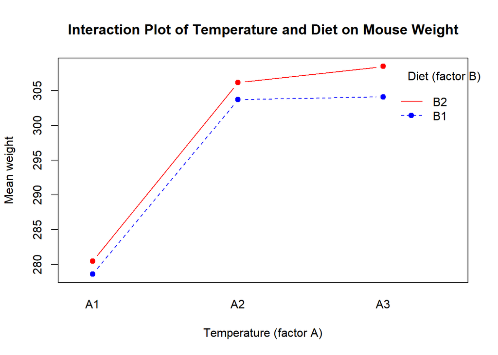

```r
# 绘制交互作用图以直观理解数据
interaction.plot(x.factor = data$A, trace.factor = data$B, response = data$Weight,
                 type = "b", col = c("blue", "red"), pch = 19,
                 xlab = "Temperature (factor A)", ylab = "Mean weight",
                 trace.label = "Diet (factor B)",
                 main = "Interaction Plot of Temperature and Diet on Mouse Weight")
```

```r
# 2. 事后多重比较（Tukey's HSD）
# 直接提取 A:B 组合的对比结果
tukey_res <- TukeyHSD(model_int, "A:B")
tukey_df <- as.data.frame(tukey_res$`A:B`)

# 3. 筛选并识别与 A2B1 组相比具有显著差异的组别
# 使用 grepl 匹配行名中包含 "A2:B1" 的所有对比对
tukey_A2B1 <- tukey_df[grepl("A2:B1", rownames(tukey_df)), ]

# 找出具有显著差异的组别（p adj < 0.05）
significant_diff_from_A2B1 <- tukey_A2B1[tukey_A2B1$`p adj` < 0.05, ]

cat("\n--- 与 A2B1 组（25°C, Standard Diet）相比具有显著差异的组别 ---\n")
```

```
--- 与 A2B1 组（25°C, Standard Diet）相比具有显著差异的组别 ---
```

```r
print(significant_diff_from_A2B1)
```

```
              diff       lwr       upr        p adj
A2:B1-A1:B1  25.09  13.27792  36.90208 8.999911e-07
A1:B2-A2:B1 -23.22 -35.03208 -11.40792 5.022745e-06
```

# 5 Question 5

## 5.1 非参数多组比较（Kruskal-Wallis test）

### 5.1.1 检验方法选择与假设陈述

由于题目明确说明数据不满足正态性和方差齐性假设，且为完全随机设计（独立样本），故采用 **Kruskal-Wallis 检验**。

- **$H_0$：**三种药物处理下，小鼠体重增加量的总体分布相同（即来自中位数相同的总体、不存在显著差异）。
- **$H_1$：**至少有一种药物处理下的小鼠体重增加量分布与其他组存在显著差异。
- **显著性水平：**$\alpha = 0.05$。

### 5.1.2 数据输入与可视化

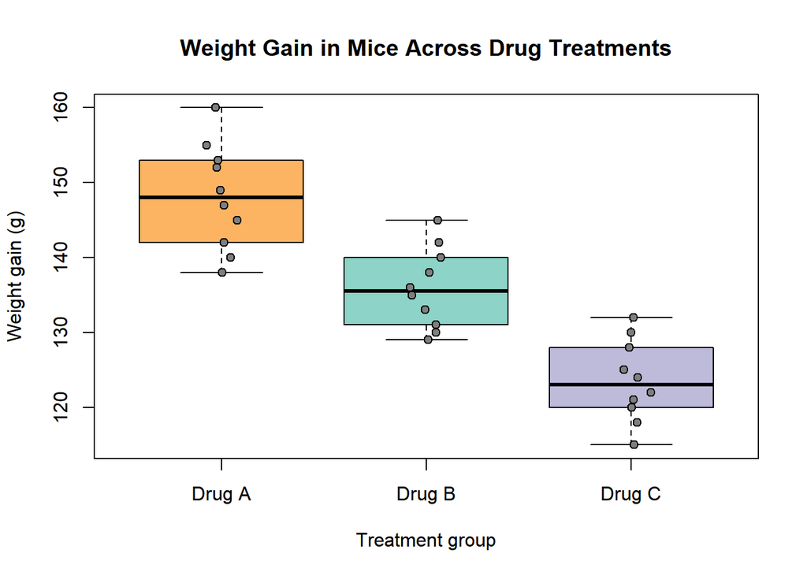

```r
# 1. 输入数据
drug_A <- c(145, 152, 138, 160, 147,
            155, 142, 149, 153, 140)
drug_B <- c(136, 129, 142, 131, 140,
            135, 138, 133, 145, 130)
drug_C <- c(120, 125, 118, 132, 121,
            128, 115, 124, 130, 122)

# 构建数据框
weight_data <- data.frame(
  WeightGain = c(drug_A, drug_B, drug_C),
  Drug = factor(rep(c("Drug A", "Drug B", "Drug C"), each = 10))
)

# 2. 数据可视化：箱线图叠加散点
boxplot(WeightGain ~ Drug, data = weight_data,
        col = c("#FDB462", "#8DD3C7", "#BEBADA"),
        main = "Weight Gain in Mice Across Drug Treatments",
        ylab = "Weight gain (g)",
        xlab = "Treatment group",
        outline = FALSE) # outline = FALSE 去掉默认的离群点显示

stripchart(WeightGain ~ Drug, data = weight_data,
           vertical = TRUE, add = TRUE, method = "jitter",
           pch = 21, bg = "grey50", col = "black")
```

### 5.1.3 执行 Kruskal-Wallis 检验

```r
# 执行 Kruskal-Wallis 检验
kw_test <- kruskal.test(WeightGain ~ Drug, data = weight_data)
kw_test
```

```
    Kruskal-Wallis rank sum test

data:  WeightGain by Drug
Kruskal-Wallis chi-squared = 22.73, df = 2, p-value = 1.159e-05
```

### 5.1.4 事后检验

已知“整体有差异”，进一步探究“究竟是哪两两药物之间存在差异”。对于 Kruskal-Wallis 检验，常用带有多重假设校正的**配对 Wilcoxon 秩和检验（Pairwise Wilcoxon Rank Sum Test）**。这里使用 BH 法控制 FDR。

*（Tukey’s HSD 依赖正态性和方差齐性假设，只能作为标准 ANOVA 的事后检验，此处不适用。）*

```r
# 执行配对 Wilcoxon 检验，并使用 BH 法进行 p 值校正
posthoc_test <- pairwise.wilcox.test(weight_data$WeightGain, weight_data$Drug,
                                     p.adjust.method = "BH", exact = FALSE)
posthoc_test
```

```
    Pairwise comparisons using Wilcoxon rank sum test with continuity correction

data:  weight_data$WeightGain and weight_data$Drug

       Drug A  Drug B
Drug B 0.00168 -
Drug C 0.00055 0.00100

P value adjustment method: BH
```